# CMC Decision Rule Description

# Set-up

This vignette will describe the decision rules used in the original method of [Song (2013)](https://tsapps.nist.gov/publication/get_pdf.cfm?pub_id=910868) and the High CMC method of [Tong et al. (2015)](https://nvlpubs.nist.gov/nistpubs/jres/120/jres.120.008.pdf). For illustrative purposes, we will consider a comparison between a known match and known non-match pair of cartridge cases from the stuy performed by [Fadul et al. (2011)](https://www.ncjrs.gov/pdffiles1/nij/grants/237960.pdf). The raw cartridge case scans can be downloaded from the [NIST Ballistics Toolmark Research Database](https://tsapps.nist.gov/NRBTD/Studies/Studies/Details/e7a8aab8-8d5a-44ac-b2be-f0de7c2ca505?nm=True&mt=1&m=3&sp=1). The scans were preprocessed using functions available in the **cmcR** package and are not discussed here. Refer to the `fadul_examples.R` script available on the [**cmcR** GitHub page](https://github.com/CSAFE-ISU/cmcR/tree/master/data-raw) for how these scans were preprocessed. We will also not discuss how similarity features are extracted from two processed scans. Refer to the documentation of the [`comparison_allTogether`](https://csafe-isu.github.io/cmcR/reference/comparison_allTogether.html) function on the **cmcR** website for information regarding this procedure.

```r
library(cmcR)
library(dplyr)
library(ggplot2)
library(purrr)
library(tidyr)
library(gridExtra)
```

We will consider comparisons between three cartridge case scans. Fadul 1-1 and Fadul 1-2 are known matches (i.e., were fired from the same firearm) while Fadul 2-1 is a non-match. The comparisons considered are Fadul 1-1 vs. Fadul 1-2 and Fadul 1-1 vs. Fadul 2-1.

```r
data("fadul1.1_processed")
data("fadul1.2_processed")
```

```r
#Download a non-matching cartridge case to Fadul 1-1 and Fadul 1-2

fadul2.1_raw <- x3ptools::read_x3p("https://tsapps.nist.gov/NRBTD/Studies/CartridgeMeasurement/DownloadMeasurement/8ae0b86d-210a-41fd-ad75-8212f9522f96")

fadul2.1_processed <- fadul2.1_raw %>%
  preProcess_crop(region = "exterior",
                  radiusOffset = -30) %>%
  preProcess_crop(region = "interior",
                  radiusOffset = 200) %>%
  preProcess_removeTrend(statistic = "quantile",
                                 tau = .5,
                                 method = "fn") %>%
  preProcess_gaussFilter() %>%
  x3ptools::sample_x3p()
```

The three processed cartridge cases are shown below.

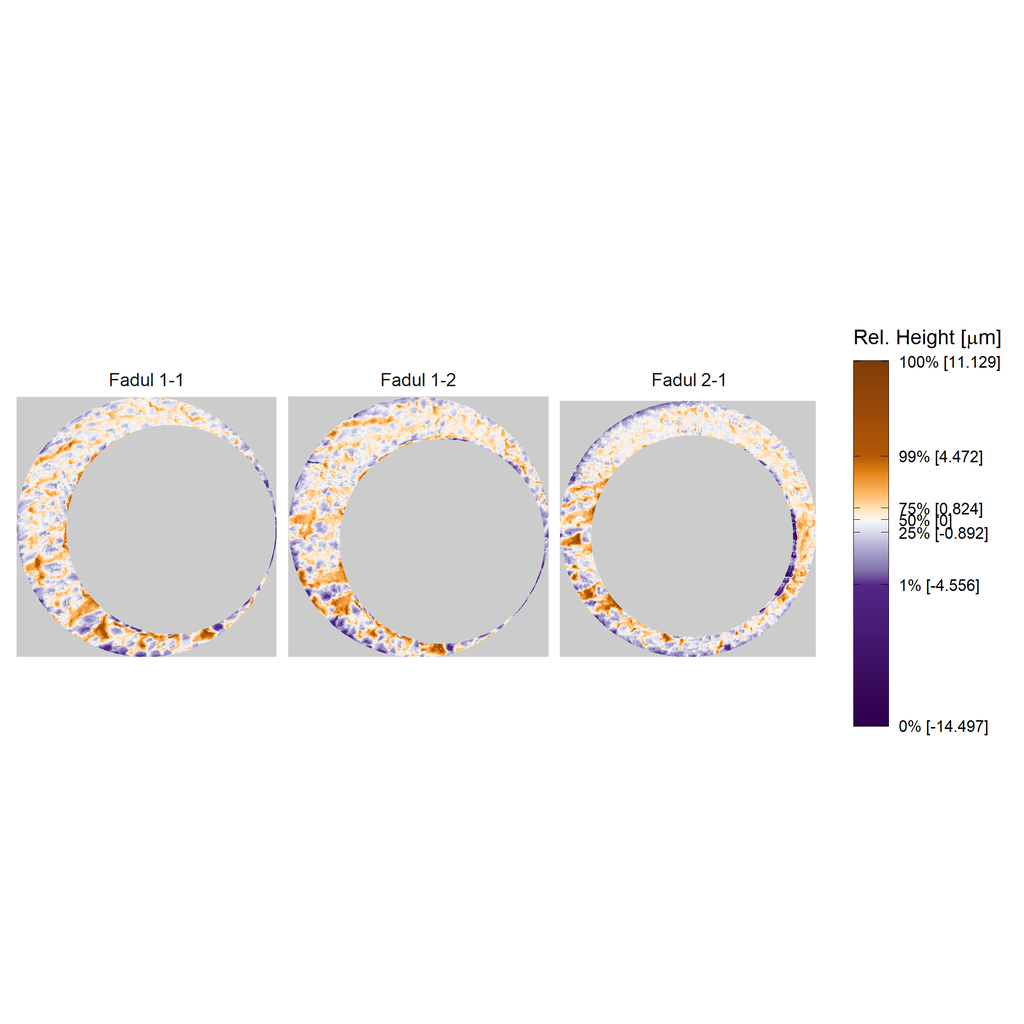

The cell-based comparison procedure implemented in the `comparison_allTogether` function returns a data frame/tibble of similarity features between two cartridge case scans. For each cell in the “reference” scan (Fadul 1-1 in this example), the similarity features include

- Estimated horizontal and vertical translations, `(x,y)`, required to align the reference cell in the target scan
- Cross-correlation between the reference cell and its associated target region after aligning by the estimated `(x,y)` values
- Rotation performed on the target scan that resulted in the `(x,y,CCF)` feature set

The fundamental assumption underlying all CMC decision rules is that truly matching cartridge case pairs should have similarity features that are consistent across the cell/region pairs. In particular, a plurality of cell/region pairs should “vote” for similar `(x, y, theta)` alignment values. In contrast, the cell/region pairs of a truly non-matching cartridge cases should have seemingly random `(x, y, theta)` votes. The two decision rules implemented in the **cmcR** package can be understood as two different systems by which cells vote for `(x, y, theta)` values that they “believe” to be the true alignment values for the overall cartridge case scans.

# Original method of [Song (2013)](https://tsapps.nist.gov/publication/get_pdf.cfm?pub_id=910868)

An actual implementation of the original method of [Song (2013)](https://tsapps.nist.gov/publication/get_pdf.cfm?pub_id=910868) is described in [Song et al. (2014)](https://doi.org/10.1088/0957-0233/25/6/064005). The decision rule [Song et al. (2014)](https://doi.org/10.1088/0957-0233/25/6/064005) describe using is based on

> a virtual reference with three reference registration parameters $\theta_{\text{ref}}$, $x_{\text{ref}}$ and $y_{\text{ref}}$ generated by the median values of the collective $\theta$, and $x$-, $y$-translation values of all cell pairs.

That is, a consensus is determined by finding the median registration phase values across the cell/region pairs for a particular cartridge case pair comparison. Then, the distances between the consensus registration values and the cell comparison values are assessed to determine whether they are within a specified distance of the consensus. This consensus assessment introduces threshold parameters $T_{x}, T_{y}, T_\theta, T_{\text{CCF}}$.

Let $x_i, y_i, \theta_i$ denote the translation and rotation parameters which produce the highest CCF for the alignment of cell/region pair $i$. Also let $x_{\text{ref}}, y_{\text{ref}}, \theta_{\text{ref}}$ be the median over alignment values for a particular cartridge case comparison (these are the “virtual reference” values). A cell/region pair $i$ is declared a match if all of the following conditions hold:

- $|x_i - x_{\text{ref}}| \leq T_{x}$
- $|y_i - y_{\text{ref}}| \leq T_{y}$
- $|\theta_i - \theta_{\text{ref}}| \leq T_{\theta}$
- CCF$_{\max,i} \geq T_{\text{CCF}}$.

With respect to the voting system analogy, we might interpret this decision rule as a single-choice voting system similar to the system used in U.S. presidential elections. That is, every cell is allowed to submit one vote corresponding to the registration phase with the highest CCF$_{\max}$ value. Some of these votes are discarded if the associated CCF$_{\max}$ are below the $T_{\text{CCF}}$ threshold. A consensus is determined by counting the number of votes that are close to the reference values $x_{\text{ref}}, y_{\text{ref}}, \theta_{\text{ref}}$ (which is dyadically defined based on the $T_x,T_y,T_{\theta}$ thresholds).

The plot below shows the values of $x_i, y_i, \theta_i$, and $CCF_{\max,i}$ for each cell/region pair between Fadul 1-1 and Fadul 1-2 as well as Fadul 1-1 and Fadul 2-1. These values are shown as blue/red bars. The purple bands indicate the range of acceptable values within $T_{x} = 20 T_{y}, T_{\theta} = 6$ within $x_{\text{ref}}, y_{\text{ref}}, \theta_{\text{ref}}$ and above $T_{\text{CCF}} = .5$ to be declared “congruent.” As we might expect, a larger proportion of $x_i, y_i, \theta_i$, and $CCF_{\max,i}$ values are within these acceptable ranges for the comparison between Fadul 1-1 and Fadul 1-2 than the comparison between Fadul 1-1 and Fadul 2-1. This indicates that there is a clearer “consensus” about the true alignment values for the matching cartridge case pair than the non-matching.

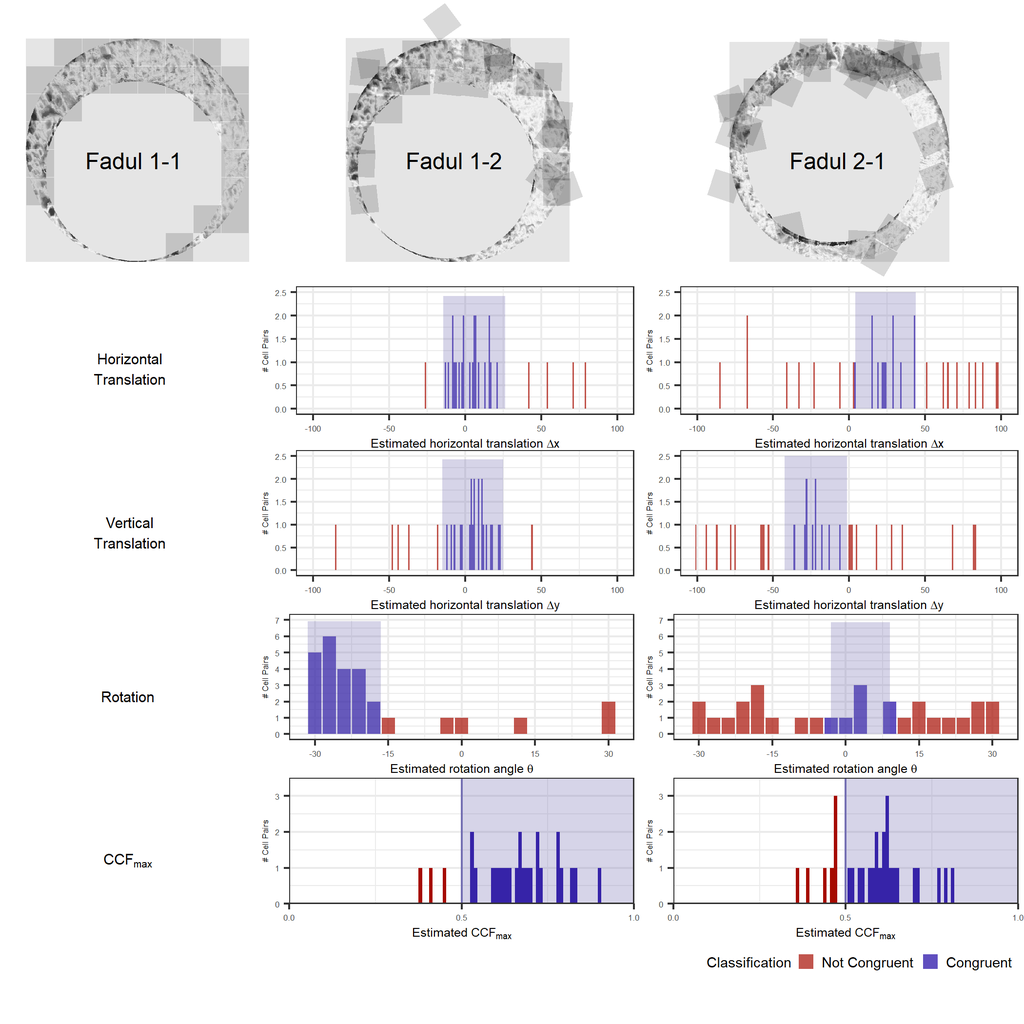

The first step in the High CMC method is to count the CMCs under the original method of [Song (2013)](https://tsapps.nist.gov/publication/get_pdf.cfm?pub_id=910868) in both comparison “directions,” meaning each scan plays the role as the “reference” and “target” scan. After these CMCs are counted, [Tong et al. (2015)](https://nvlpubs.nist.gov/nistpubs/jres/120/jres.120.008.pdf) propose using the minimum of the 2 CMC counts as an initial CMC count prior to applying the High CMC decision rule. The figure below shows the behavior of the $x_i, y_i, \theta_i$, and $CCF_{\max,i}$ values in each direction via a [parallel-coordinates plot](https://en.wikipedia.org/wiki/Parallel_coordinates), which is useful for visualizing multi-dimensional data sets. Each connected path represents a single cell/region pair. The purple regions again represent the acceptable regions that are sufficiently “close” to the reference values (or above .5 in the case of the CCF). Paths that only traverse through purple regions are deemed congruent under the decision rule of the original method of [Song (2013)](https://tsapps.nist.gov/publication/get_pdf.cfm?pub_id=910868) and are colored blue. We can see that 19 cells are deemed congruent for the comparison in which Fadul 1-1 is treated as the reference while 18 are considered congruent in the other direction. As such, the initial CMC count used for the High CMC method would be 18.

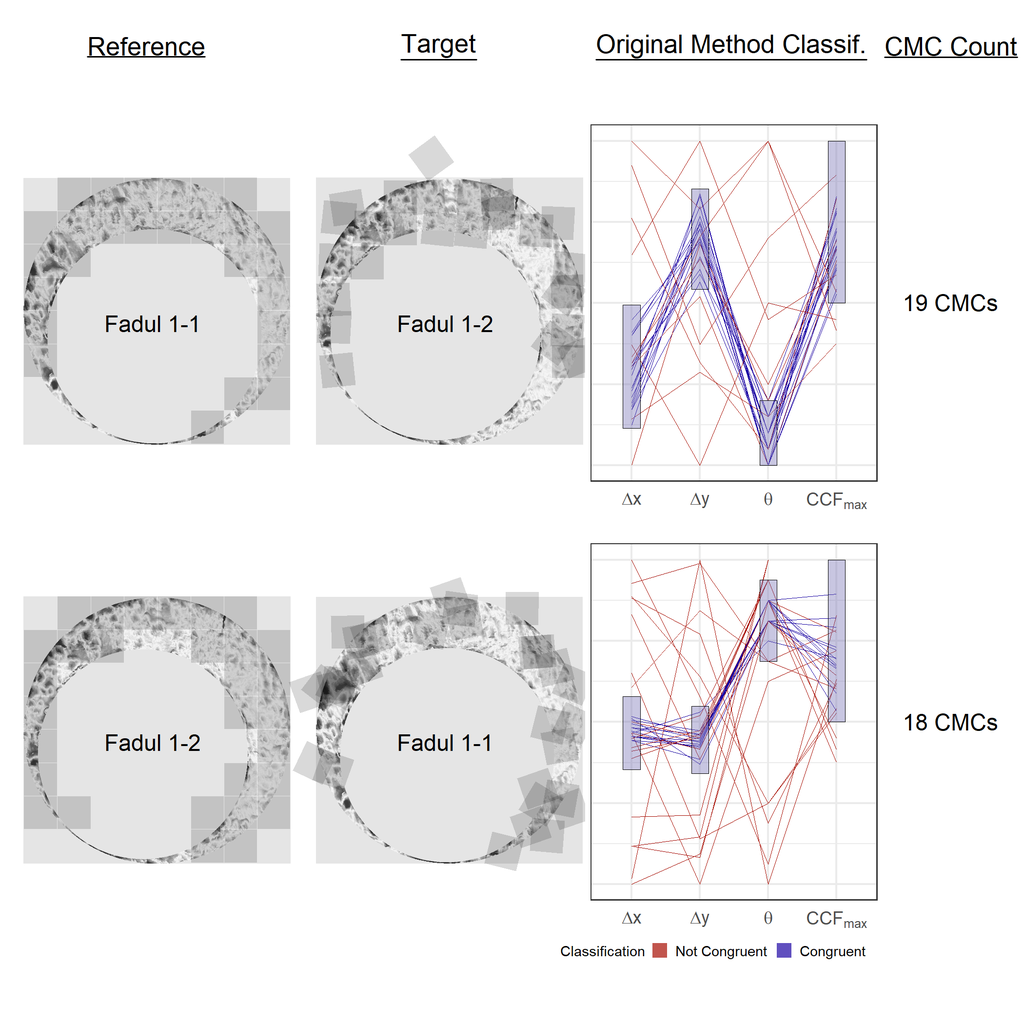

By considering only the “top vote” of each cell as is done in the decision rule of the original method of [Song (2013)](https://tsapps.nist.gov/publication/get_pdf.cfm?pub_id=910868), information is lost regarding other registration phases for which a cell might also rank highly. As [Tong et al. (2015)](https://nvlpubs.nist.gov/nistpubs/jres/120/jres.120.008.pdf) observe:

> some of the valid cell pairs may be mistakenly excluded from the CMC count because by chance their correlation yields a higher CCF value at a rotation angle outside the threshold range $T_\theta$.

> [i]f two images are truly matching, the CMC-$\theta$ distribution of matching image pairs should have a prominent peak located near the initial phase angle $\Theta_0$, while non-matching image pairs may have a relatively flat and random CMC-$\theta$ distribution pattern.

An example of the CMC-$\theta$ distribution for the comparison between Fadul 1-1 and Fadul 1-2 is shown below. We can see that, conditional on $\theta = -24$ degrees, more cells tend to have similar `x, y` values than conditional on $\theta = 30$. The CCF values are also larger. This indicates that $\theta = -24$ is likely closer to the “true” rotation than $\theta = 30$ or elsewhere. The two darker-shaded bars represent the $\theta$ values that have a “High CMC” count as described above. Because these $\theta$ values are adjacent rather than being far from each other, there is evidence that the “true” $\theta$ value is approximately $\theta = -24$ or $-27$ degrees. We say that this comparison direction would “pass” the High CMC criteria because the $\theta$ values with high CMC counts are adjacent.

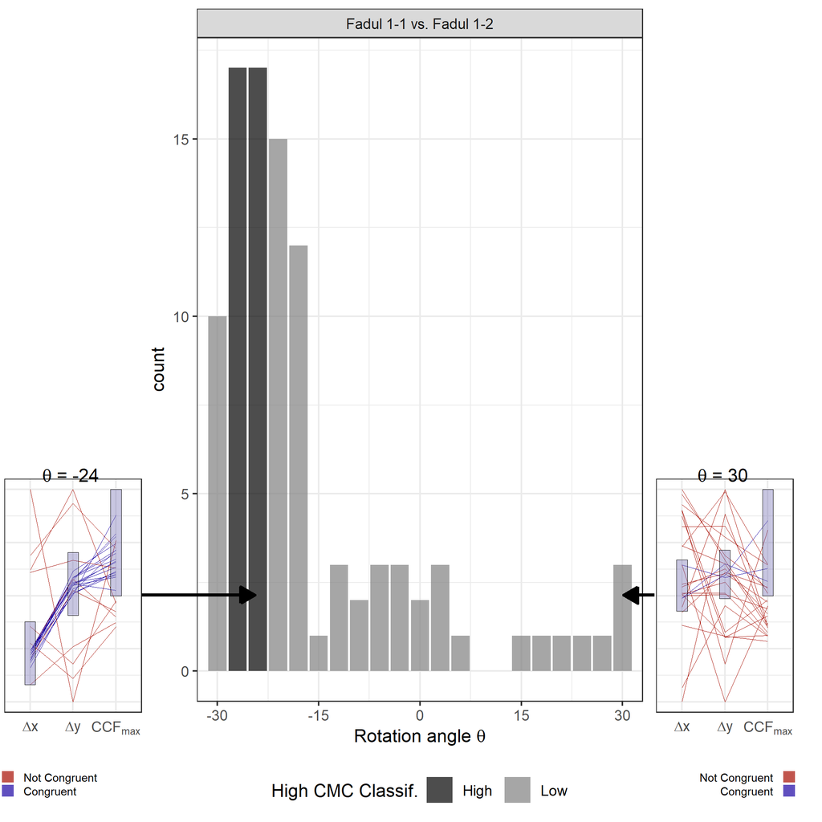

> Conduct both forward and backward correlations at each rotation and record the registration based on CCF$_{\max}$, $x$, and $y$ for each cell at each rotation. These data will be used in the next two steps separately.

> Build CMC-$\theta$ distributions using the data generated in step 1, by counting the number of cells that have congruent positions at each individual rotation angle. Calculate the angular range of “high CMCs” using both the forward and backward CMC-$\theta$ distributions, as illustrated in Figs. 2 and 3.

> If the angular range of the “high CMCs” is within the range $T_\theta$, identify the CMCs for each rotation angle in this range and combine them to give the number of CMCs for this comparison in place of the original CMC number. In this step, if the range is narrower than $T_\theta$, the nearby angles are included to make the range equal to $T_\theta$; CMCs with same index in each rotation are only counted once.

The “prominent peak” empirical observation upon which the High CMC method is based does seem to hold for many known match and known non-match pairs in our experience. However, we’ve observed that the behavior of the CMC-$\theta$ distributions depend heavily on the preprocessing procedures used and thresholds set. In particular, the CMC-$\theta$ distributions for some KNM pairs exhibit the prominent peak behavior for a wide range of threshold values making them difficult to distinguish from KM pairs.